# Bike Share Predictions: Boston

Anushka Samant

2023-11-10

# Introduction

Bike share programs have become integral components of urban transportation, offering an accessible and environmentally conscious solution for short-distance travel. According to a Bloomberg article, “*Ridership in major US cities has increased 27% since 2019, reaching almost 45 million annual trips.*” In cities like Boston, these bike share systems rely on strategically placed docking stations where users can pick up and drop off bikes. However, the dynamic nature of user demand across different locations and times poses a challenge known as the re-balancing problem. The crux of this challenge lies in maintaining an equilibrium of available bikes and docking spaces throughout the network. Without an effective re-balancing strategy, certain stations may experience shortages or surpluses, impacting user satisfaction and system efficiency.

```r
knitr::opts_chunk$set(echo = TRUE, warning = FALSE, message = FALSE, fig.align = 'left', cache = TRUE)

library(tidyverse)
library(kableExtra)
library(caret)
library(knitr)
library(pscl)
library(plotROC)
library(pROC)
library(lubridate)
library(pbkrtest)
library(lme4)
library(Matrix)
library(sjPlot)
library(sf)
library(tigris)
library(tidycensus)
library(viridis)
library(riem)
library(gridExtra)
library(RSocrata)
library(gganimate)
library(gifski)
library(spdep)
library(spDataLarge)

#install.packages('spDataLarge', repos='https://nowosad.github.io/drat/', type='source')

palette5 <- c("#440154","#3b528b","#21918c","#5ec962","#fde725")
palette4 <- c("#3b528b","#21918c","#5ec962","#fde725")
palette2 <- c("#3b528b","#5ec962")

setwd("D:\\OneDrive - PennO365\\Semester 3\\PPA\\HW6")

# functions
root.dir = "https://raw.githubusercontent.com/urbanSpatial/Public-Policy-Analytics-Landing/master/DATA/"
source("https://raw.githubusercontent.com/urbanSpatial/Public-Policy-Analytics-Landing/master/functions.r")
```

# Data

### Bluebike Data

We use Bluebike data downloaded from https://s3.amazonaws.com/hubway-data/index.html for the month of August and September 2022.

```r
aug <- read.csv("202208-bluebikes-tripdata.csv")
sept <- read.csv("202209-bluebikes-tripdata.csv")
#oct <- read.csv("202210-bluebikes-tripdata.csv")
bluebike <- rbind(aug, sept)
bluebike <- bluebike %>%
  mutate(interval60 = floor_date(ymd_hms(starttime), unit = "hour"),
         interval15 = floor_date(ymd_hms(starttime), unit = "15 mins"),
         week = week(interval60),
          dotw = wday(interval60, label=TRUE))%>%
   filter(week > 34)
```

### Census Data

We use ACS Data 2021 to get demographic information for Suffolk, Middlesex, and Norfolk counties across which the Greater Boston Area spans. The utilization of Census Data allows us to examine the socioeconomic characteristics that might be correlated with the ridership of bike share trips. By merging census data with the origin and destination stations of bike share trips, we try to see potential relationships between the demographic or socioeconomic makeup of a region and the usage patterns of bike-sharing services. For the purpose of this model, we can look at the mean commute time.

```r
bostonCensus <-
  get_acs(geography = "tract",
          variables = c("B01003_001", "B19013_001",
                        "B02001_002", "B08013_001",
                        "B08012_001", "B08301_001",
                        "B08301_010", "B01002_001"),
          year = 2021,
          state = "MA",
          geometry = TRUE,
          county=c("Suffolk", "Middlesex", "Norfolk"),
          output = "wide") %>%
  rename(Total_Pop =  B01003_001E,
         Med_Inc = B19013_001E,
         Med_Age = B01002_001E,
         White_Pop = B02001_002E,
         Travel_Time = B08013_001E,
         Num_Commuters = B08012_001E,
         Means_of_Transport = B08301_001E,
         Total_Public_Trans = B08301_010E) %>%
  select(Total_Pop, Med_Inc, White_Pop, Travel_Time,
         Means_of_Transport, Total_Public_Trans,
         Med_Age,
         GEOID, geometry) %>%
  mutate(Percent_White = White_Pop / Total_Pop,
         Mean_Commute_Time = Travel_Time / Total_Public_Trans,
         Percent_Taking_Public_Trans = Total_Public_Trans / Means_of_Transport *100)

bostonTracts <-
  bostonCensus %>%
  as.data.frame() %>%
  distinct(GEOID, .keep_all = TRUE) %>%
  select(GEOID, geometry) %>%
  st_sf

bluebike_census <- st_join(bluebike %>%
          filter(is.na(start.station.longitude) == FALSE &
                   is.na(start.station.latitude) == FALSE &
                   is.na(end.station.longitude) == FALSE &
                   is.na(end.station.latitude) == FALSE) %>%
          st_as_sf(., coords = c("start.station.longitude", "start.station.latitude"), crs = 4326),
        bostonTracts %>%
          st_transform(crs=4326),
        join=st_intersects,
              left = TRUE) %>%
  rename(Origin.Tract = GEOID) %>%
  mutate(start.station.longitude = unlist(map(geometry, 1)),
         start.station.latitude = unlist(map(geometry, 2)))%>%
  as.data.frame() %>%
  select(-geometry)%>%
  st_as_sf(., coords = c("end.station.longitude", "end.station.latitude"), crs = 4326) %>%
  st_join(., bostonTracts %>%
            st_transform(crs=4326),
          join=st_intersects,
          left = TRUE) %>%
  rename(Destination.Tract = GEOID)  %>%
  mutate(end.station.longitude = unlist(map(geometry, 1)),
         end.station.latitude = unlist(map(geometry, 2)))%>%
  as.data.frame() %>%
  select(-geometry)
```

### Weather Data

Import weather data from Boston airport (code BOS) for the five weeks using `riem_measures`. We can `mutate` the data to get temperature, wind speed, precipitation on an hourly basis and plot the temperature and precipitation trends over our study period. Analyzing this data can provide insights into whether weather conditions have a substantial impact on ridership.

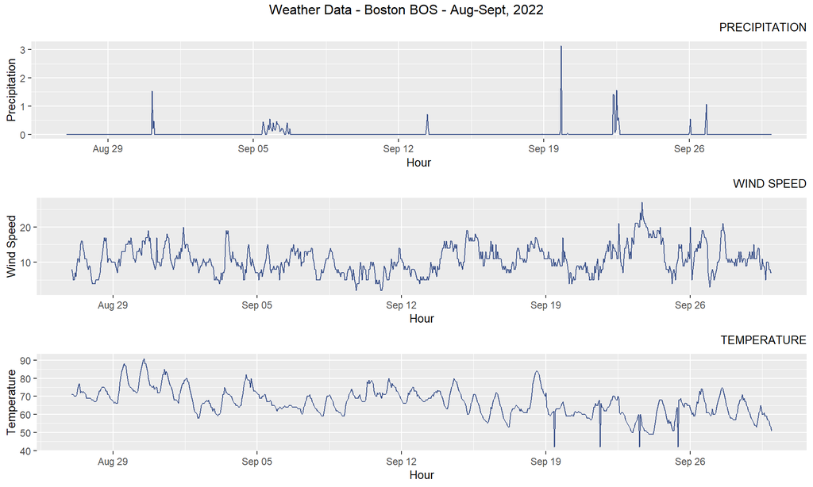

```r
weather.panel <-
  riem_measures(station = "BOS", date_start = "2022-08-27", date_end = "2022-09-30") %>%
  dplyr::select(valid, tmpf, p01i, sknt)%>%
  replace(is.na(.), 0) %>%
    mutate(interval60 = ymd_h(substr(valid,1,13))) %>%
    mutate(week = week(interval60),
           dotw = wday(interval60, label=TRUE)) %>%
    group_by(interval60) %>%
    summarize(Temperature = max(tmpf),
              Precipitation = sum(p01i),
              Wind_Speed = max(sknt)) %>%
    mutate(Temperature = ifelse(Temperature == 0, 42, Temperature))

grid.arrange(top = "Weather Data - Boston BOS - Aug-Sept, 2022",
  ggplot(weather.panel, aes(interval60, Precipitation)) + geom_line(color = "#3b528b") +
    labs(title="PRECIPITATION", x="Hour", y="Precipitation")+
      theme(plot.title = element_text(size = 10, hjust = 1, vjust = 2),
            axis.title = element_text(size = 10)),
  ggplot(weather.panel, aes(interval60, Wind_Speed)) + geom_line(color = "#3b528b") +
    labs(title="WIND SPEED", x="Hour", y="Wind Speed")+
      theme(plot.title = element_text(size = 10, hjust = 1, vjust = 2),
            axis.title = element_text(size = 10)),
  ggplot(weather.panel, aes(interval60, Temperature)) + geom_line(color = "#3b528b") +
    labs(title="TEMPERATURE", x="Hour", y="Temperature")+
      theme(plot.title = element_text(size = 10, hjust = 1, vjust = 2),
            axis.title = element_text(size = 10))) +
  theme_light()
```

### Feature Engineering

Bluebike’s analysis of trip data from 2020 suggests that the most active stations are concentrated in Cambridge, particularly near large educational campuses. This finding aligns logically with the prevalence of educational institutions in the Greater Boston area. Typically, residents in these areas, falling within the 18-30 age range, show a greater inclination toward using bikes. Consequently, factoring in the proximity of bike stations to educational institutes could be valuable when making decisions about station placement or optimizing services.

*(Note: this consideration was not included in the final analysis due to computational errors.)*

```r
# library(sf)
# bike_stations <- st_as_sf(bluebike_census, coords = c("start.station.longitude", "start.station.latitude"), crs = 4326)
#
# college <- st_read("E:\\Downloads\\colleges") %>%
#   st_transform(college, crs = 4326)
#
# college <- college[!duplicated(st_coordinates(college)), ]
#
# nearest_college <- st_nearest_feature(st_coordinates(bike_stations), st_coordinates(college))
#
# # Calculate distances to colleges
# bluebike_census$distance_to_colleges <- st_distance(bike_stations, nearest_college)

#
# library(sf)
# library(dplyr)
#
# bike_stations <- st_as_sf(bluebike_census, coords = c("start.station.longitude", "start.station.latitude"), crs = 4326)
#
# college <- st_read("E:\\Downloads\\colleges") %>%
#   st_transform(crs = 4326)
#
# bike_stations <- bike_stations %>%
#   group_by(start.station.name) %>%
#   mutate(
#     college_dist = st_distance(., college)  # This calculates distance between each bike station and all colleges
#   ) %>%
#   summarise(
#     min_college_dist = min(college_dist),  # This gets the minimum distance for each bike station
#     .groups = 'drop'
#   )
#
# # Merge the results back to the original dataset
# bluebike_census <- left_join(bluebike_census, bike_stations, by = "start.station.name")
#
# # Now, bluebike_census contains the calculated distances in the 'college_dist' column
```

### Time Lags and Holidays

```r
bike.panel <-
  expand.grid(interval60=unique(bluebike_census$interval60),
              start.station.name = unique(bluebike_census$start.station.name)) %>%
  left_join(., bluebike_census %>%
              dplyr::select(start.station.name, Origin.Tract, start.station.longitude, start.station.latitude)%>%
              distinct() %>%
              group_by(start.station.name) %>%
              slice(1))

# length(unique(bike_census$interval60)) * length(unique(bike_census$start_station))
# nrow(bike.panel)

bike.panel <-
  bluebike_census %>%
  mutate(Trip_Counter = 1) %>%
  right_join(bike.panel) %>%
  group_by(interval60, start.station.name, Origin.Tract, start.station.longitude, start.station.latitude) %>% # group by nn
  summarize(Trip_Count = sum(Trip_Counter, na.rm=T)) %>%
  left_join(weather.panel, by = "interval60") %>%
  ungroup() %>%
  filter(is.na(start.station.name) == FALSE) %>%
  mutate(week = week(interval60),
         dotw = wday(interval60, label = TRUE)) %>%
  filter(is.na(Origin.Tract) == FALSE)

bike.panel <-
  bike.panel %>%
  arrange(start.station.name, interval60) %>%
  mutate(lagHour = dplyr::lag(Trip_Count,1),
         lag2Hours = dplyr::lag(Trip_Count,2),
         lag3Hours = dplyr::lag(Trip_Count,3),
         lag4Hours = dplyr::lag(Trip_Count,4),
         lag12Hours = dplyr::lag(Trip_Count,12),
         lag1day = dplyr::lag(Trip_Count,24),
         holiday = ifelse(yday(interval60) == 248,1,0)) %>%
   mutate(day = yday(interval60)) %>%
   mutate(holidayLag = case_when(dplyr::lag(holiday, 1) == 1 ~ "PlusOneDay",
                                 dplyr::lag(holiday, 2) == 1 ~ "PlusTwoDays",
                                 dplyr::lag(holiday, 3) == 1 ~ "PlusThreeDays",
                                 dplyr::lead(holiday, 1) == 1 ~ "MinusOneDay",
                                 dplyr::lead(holiday, 2) == 1 ~ "MinusTwoDays",
                                 dplyr::lead(holiday, 3) == 1 ~ "MinusThreeDays"),
         holidayLag = ifelse(is.na(holidayLag) == TRUE, 0, holidayLag))

as.data.frame(bike.panel) %>%
    group_by(interval60) %>%
    summarise_at(vars(starts_with("lag"), "Trip_Count"), mean, na.rm = TRUE) %>%
    gather(Variable, Value, -interval60, -Trip_Count) %>%
    mutate(Variable = factor(Variable, levels=c("lagHour","lag2Hours","lag3Hours","lag4Hours",
                                                "lag12Hours","lag1day")))%>%
    group_by(Variable) %>%
    summarize(correlation = round(cor(Value, Trip_Count),2))
```

```
## # A tibble: 6 × 2
##   Variable   correlation
##   <fct>            <dbl>
## 1 lagHour           0.9
## 2 lag2Hours         0.71
## 3 lag3Hours         0.52
## 4 lag4Hours         0.33
## 5 lag12Hours       -0.62
## 6 lag1day           0.85
```

# Exploratory Data Analysis

The plot below shows the number of bike share trips per hour during the five weeks. Most weeks exhibit remarkably comparable time series patterns with consistent peaks and troughs. This suggests the presence of serial correlation. The decreasing ridership towards the end of the month might be explained by the colder weather in Fall season. You can also see the sharp decline in the no. of trips on Sept 5, Labor Day Holiday.

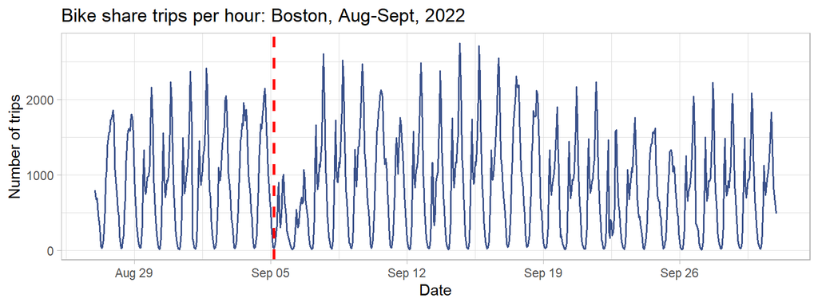

```r
ggplot(bluebike_census %>%
         group_by(interval60) %>%
         tally()) +
  geom_line(aes(x = interval60, y = n), color = "#3b528b", linewidth = 0.7) +
  geom_vline(xintercept = as.numeric(as.POSIXct("2022-09-05")), linetype = "dashed", color = "red", linewidth = 1) +
  labs(title = "Bike share trips per hour: Boston, Aug-Sept, 2022",
       x = "Date",
       y = "Number of trips") +
  theme_light()
```

We look at when people use bike stations the most by looking at the patterns of ridership over time. We use histograms that show the average number of trips per station. From the plots, we can see that there are some times with a lot of bike rides (high volume) and many times with fewer rides (low volume). We see variance in one particular section of stations during Mid-Day, PM Rush and Overnight.

During the evening rush hours (PM rush), more people use the bike stations, so these times have higher demand. This suggests that it could be a good idea to send notifications to users during these busy times, encouraging them to move bikes to different stations. This way, users might get rewards or incentives for helping balance the bikes at stations, especially during the high-demand PM rush hours when people are done with work.

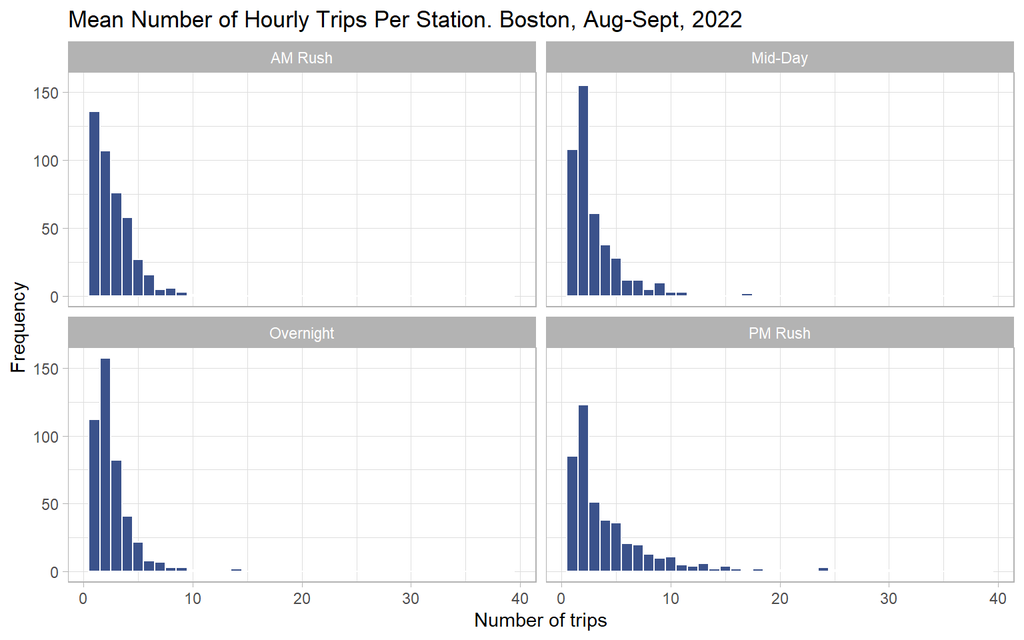

```r
bluebike_census %>%
        mutate(time_of_day = case_when(hour(interval60) < 7 | hour(interval60) > 18 ~ "Overnight",
                                 hour(interval60) >= 7 & hour(interval60) < 10 ~ "AM Rush",
                                 hour(interval60) >= 10 & hour(interval60) < 15 ~ "Mid-Day",
                                 hour(interval60) >= 15 & hour(interval60) <= 18 ~ "PM Rush"))%>%
         group_by(interval60, start.station.name, time_of_day) %>%
         tally()%>%
  group_by(start.station.name, time_of_day)%>%
  summarize(mean_trips = mean(n))%>%
  ggplot()+
  geom_histogram(aes(mean_trips), binwidth = 1, fill = "#3b528b", color = "white")+
  labs(title="Mean Number of Hourly Trips Per Station. Boston, Aug-Sept, 2022",
       x="Number of trips",
       y="Frequency")+
  facet_wrap(~time_of_day) +
  theme_light()
```

Here we visualize the distribution of the number of trips per hour for different bike stations in Boston during August and September 2022.

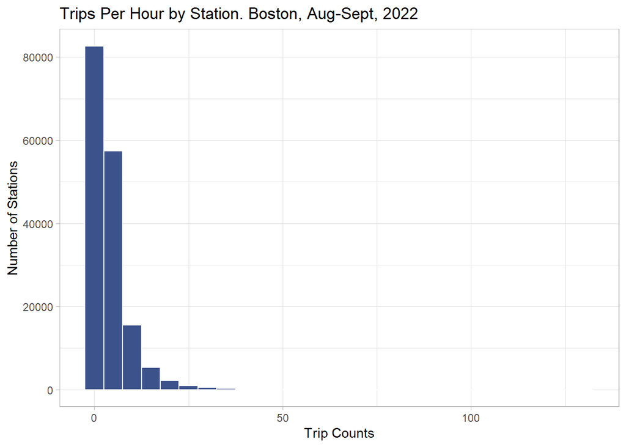

```r
ggplot(bluebike_census %>%
         group_by(interval60, start.station.name) %>%
         tally())+
  geom_histogram(aes(n), binwidth = 5, fill = "#3b528b", color = "white")+
  labs(title="Trips Per Hour by Station. Boston, Aug-Sept, 2022",
       x="Trip Counts",
       y="Number of Stations")+
  theme_light()
```

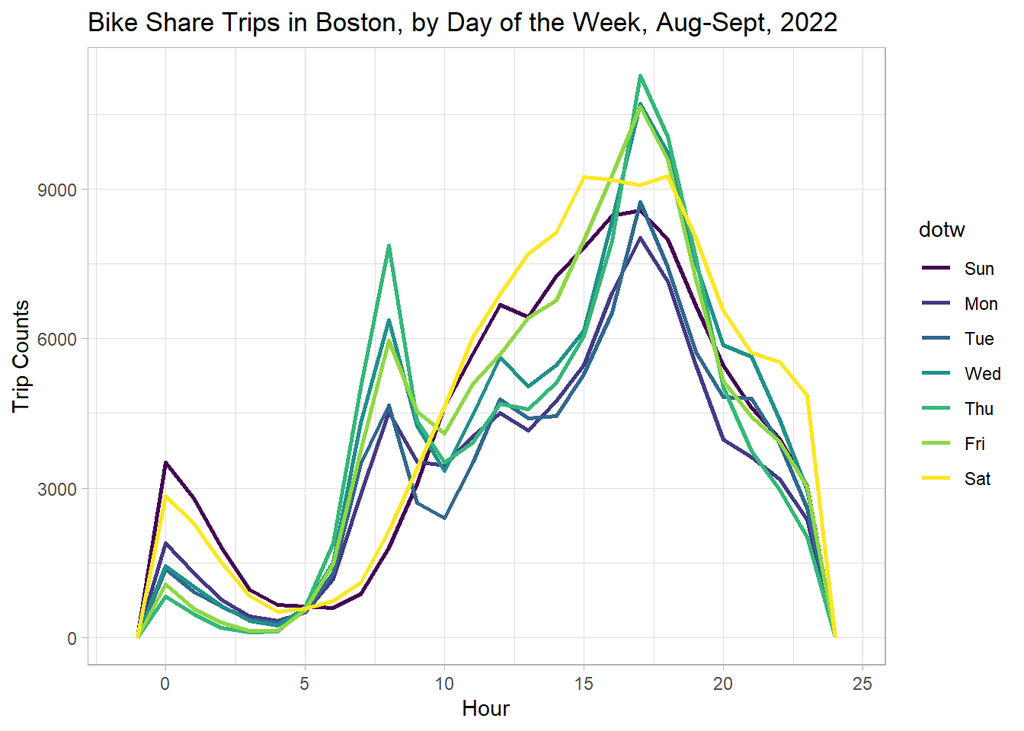

```r
ggplot(bluebike_census %>% mutate(hour = hour(interval60)))+
     geom_freqpoly(aes(hour, color = dotw), binwidth = 1, size = 1)+
  labs(title="Bike Share Trips in Boston, by Day of the Week, Aug-Sept, 2022",
       x="Hour",
       y="Trip Counts")+
  theme_light()
```

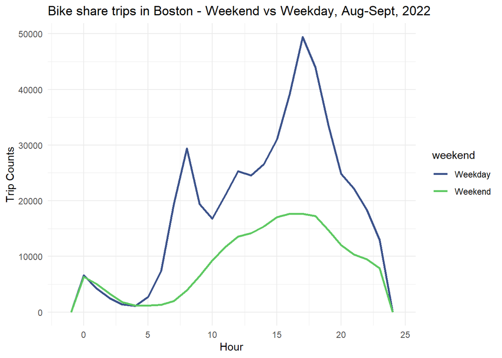

```r
ggplot(bluebike_census %>%
         mutate(hour = hour(interval60),
                weekend = ifelse(dotw %in% c("Sun", "Sat"), "Weekend", "Weekday")))+
     geom_freqpoly(aes(hour, color = weekend), binwidth = 1, size = 1)+
  scale_color_manual(values = c("#3b528b", "#5ec962")) +
  labs(title="Bike share trips in Boston - Weekend vs Weekday, Aug-Sept, 2022",
       x="Hour",
       y="Trip Counts")+
  theme_minimal()
```

Besides examining the time-based trends, we’re also exploring where bike rides are most popular across the city. Our maps reveal that there’s a notable concentration of bike share trips in one particular region, particularly during the evening rush hours. This suggests a higher demand for refilling or restocking bikes in the Cambridge-Brookline-Boston area after people finish their work in the evening.

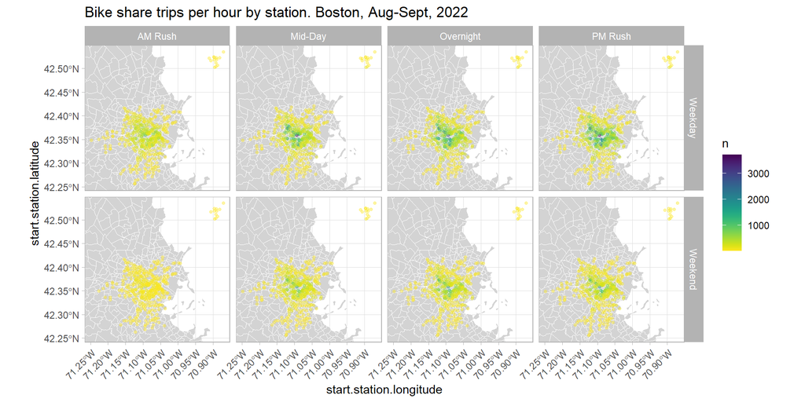

```r
ggplot()+
  geom_sf(data = bostonCensus %>%
          st_transform(crs=4326), fill = "lightgray", color = "white")+
  geom_point(data = bluebike_census %>%
            mutate(hour = hour(interval60),
                weekend = ifelse(dotw %in% c("Sun", "Sat"), "Weekend", "Weekday"),
                time_of_day = case_when(hour(interval60) < 7 | hour(interval60) > 18 ~ "Overnight",
                                 hour(interval60) >= 7 & hour(interval60) < 10 ~ "AM Rush",
                                 hour(interval60) >= 10 & hour(interval60) < 15 ~ "Mid-Day",
                                 hour(interval60) >= 15 & hour(interval60) <= 18 ~ "PM Rush"))%>%
              group_by(start.station.name, start.station.latitude, start.station.longitude, weekend, time_of_day) %>%
              tally(),
            aes(x = start.station.longitude, y = start.station.latitude, color = n),
            fill = "transparent", alpha = 0.4, size = 1)+
  scale_colour_viridis(direction = -1,
  discrete = FALSE, option = "D")+
  ylim(min(bluebike_census$start.station.latitude), max(bluebike_census$start.station.latitude))+
  xlim(min(bluebike_census$start.station.longitude), max(bluebike_census$start.station.longitude))+
  facet_grid(weekend ~ time_of_day)+
  labs(title="Bike share trips per hour by station. Boston, Aug-Sept, 2022")+
  theme_light() +
  theme(axis.text.x = element_text(angle = 45, hjust = 1))
```

To make it easier to understand the bike share trips, we create an animated map that shows how they change over time and space. This visual representation combines both the temporal (time-related) and spatial (location-related) aspects, providing a dynamic and intuitive way to see the patterns and trends in bike sharing activity.

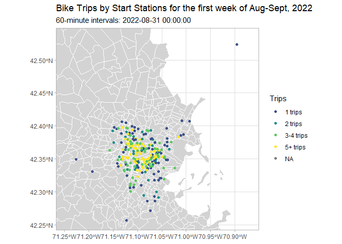

```r
stations<-
  bluebike %>%
  dplyr::select(start.station.name, start.station.longitude, start.station.latitude) %>%
  group_by(start.station.name) %>%
  distinct()%>%
  filter(is.na(start.station.longitude) == FALSE &
           is.na(start.station.latitude) == FALSE) %>%
  st_as_sf(., coords = c("start.station.longitude", "start.station.latitude"), crs = 4326)


one_day <-
  bluebike_census %>%
  filter(week == 35 & dotw == "Wed")

one_day.panel <-
  expand.grid(
    interval60 = unique(one_day$interval60),
    Origin.Tract = unique(bike.panel$Origin.Tract))

animation_data <-
  mutate(one_day, Trip_Counter = 1) %>%
  right_join(one_day) %>%
  group_by(interval60, start.station.name) %>%
  summarise(Trip_Count = sum(Trip_Counter, na.rm=T)) %>%
  ungroup() %>%
  right_join(stations, by=c("start.station.name" = "start.station.name")) %>%
  st_sf() %>%
  mutate(Trips = case_when(Trip_Count == 0 ~ "0 trips",
                           Trip_Count == 1 ~ "1 trips",
                           Trip_Count == 2 ~ "2 trips",
                           Trip_Count > 2 & Trip_Count <= 4 ~ "3-4 trips",
                           Trip_Count > 4 ~ "5+ trips")) %>%
  mutate(Trips  = fct_relevel(Trips, "0 trips","1 trips","2 trips",
                              "3-4 trips","5+ trips"))

# suffolk_county_extents <- list(
#   min_longitude = -71.0820,
#   max_longitude = -70.6100,
#   min_latitude = 42.2279,
#   max_latitude = 42.5083)

bike_animation <- ggplot() +
  geom_sf(data = bostonCensus %>% st_transform(crs = 4326), fill = "lightgray", color = "white") +
  geom_sf(data = animation_data, aes(color = Trips), size = 1.5) +
  scale_color_manual(values = palette4) +
  ylim(min(bluebike_census$start.station.latitude), max(bluebike_census$start.station.latitude)) +
  xlim(min(bluebike_census$start.station.longitude), max(bluebike_census$start.station.longitude)) +
  labs(title = "Bike Trips by Start Stations for the first week of Aug-Sept, 2022",
       subtitle = "60-minute intervals: {current_frame}") +
  transition_manual(interval60) +
  theme_light()

animate(bike_animation, duration=10, renderer = gifski_renderer())
```

In order to build our training dataset comprehensively, it’s crucial to ensure that every unique combination of stations and hours/days is included. This ensures the creation of a “panel” or time-series dataset where each row represents a specific time period in the study, whether or not any observations occurred during that time. Even if a station had no trips originating from it at a particular hour, we still include that combination in the dataset with a value of zero, ensuring a complete representation of all possible station-hour combinations.

# Regressions

In this analysis, we’re exploring five different regression models, each using a different set of independent variables:

Regression A: Includes time features and temperature. Regression B: Includes time features, temperature, and start station. Regression C: Includes time features, temperature, start station, and precipitation. Regression D: Includes time features, temperature, start station, precipitation, and lag features. Regression E: Includes time features, temperature, start station, precipitation, lag features, and holiday information.

The process involves training each model using the data from the first three weeks of trip records. After training, we use these models to predict ridership using the data from the last two weeks. Subsequently, we calculate the errors associated with each model, providing insights into how well each model performs in predicting ridership during the specified time period.

```r
set.seed(123)
bike.Train <- filter(bike.panel, week < 38)
bike.Test <- filter(bike.panel, week >= 38)

# unique(bike.Train$holiday)
# table(bike.Train$holiday)
# unique(bike.Test$holiday)

reg1 <-
  lm(Trip_Count ~  hour(interval60) + dotw + Temperature,  data=bike.Train)

reg2 <-
  lm(Trip_Count ~  start.station.name + dotw + Temperature,  data=bike.Train)

reg3 <-
  lm(Trip_Count ~  start.station.name + hour(interval60) + dotw + Temperature + Precipitation,
     data=bike.Train)

reg4 <-
  lm(Trip_Count ~  start.station.name +  hour(interval60) + dotw + Temperature + Precipitation +
                   lagHour + lag2Hours +lag3Hours + lag12Hours + lag1day,
     data=bike.Train)

reg5 <-
  lm(Trip_Count ~  start.station.name + hour(interval60) + dotw + Temperature + Precipitation +
                   lagHour + lag2Hours +lag3Hours +lag12Hours + lag1day + holidayLag + holiday,
     data=bike.Train)
```

We then use the different regression models (A to E) to predict bike ride counts for each week in the test dataset. We calculate the absolute errors between the predicted and observed values, computes the mean absolute error (MAE) for each week and model. This helps us identify which model, and thus which combination of independent variables, yields the most accurate and reliable predictions for bike ride counts during the specified weeks.

```r
bike.Test.weekNest <-
  bike.Test %>%
  nest(data = -week)

model_pred <- function(dat, fit){
   pred <- predict(fit, newdata = dat)}

week_predictions <-
  bike.Test.weekNest %>%
    mutate(A_Time_FE = map(.x = data, fit = reg1, .f = model_pred),
           B_Space_FE = map(.x = data, fit = reg2, .f = model_pred),
           C_Time_Space_FE = map(.x = data, fit = reg3, .f = model_pred),
           D_Time_Space_FE_timeLags = map(.x = data, fit = reg4, .f = model_pred),
           E_Time_Space_FE_timeLags_Holiday = map(.x = data, fit = reg5, .f = model_pred)) %>%
    gather(Regression, Prediction, -data, -week) %>%
    mutate(Observed = map(data, pull, Trip_Count),
           Absolute_Error = map2(Observed, Prediction,  ~ abs(.x - .y)),
           MAE = map_dbl(Absolute_Error, mean, na.rm = TRUE),
           sd_AE = map_dbl(Absolute_Error, sd, na.rm = TRUE))
```

### MAE

The graph depicts the Mean Absolute Error (MAE) for each week and model. Based on the bar chart, Regression Models D and E demonstrate the most precise predictions for bike rides. Model E, with a slightly superior MAE, is chosen as the optimal model. This indicates that integrating time lags into the model substantially improves its ability to predict future ridership. In simpler terms, accounting for historical patterns and trends in bike rides enhances the accuracy of predicting upcoming ridership.

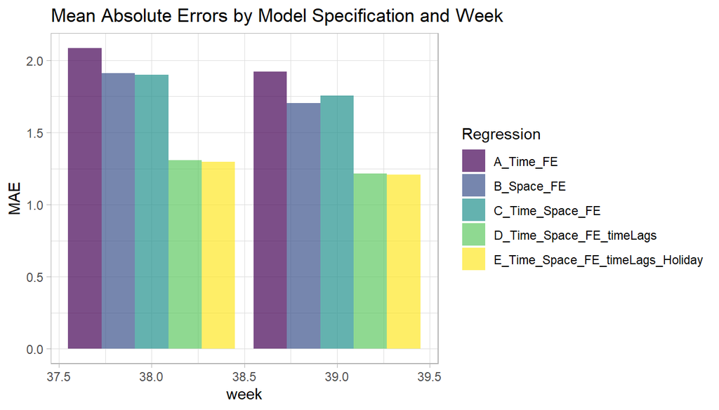

```r
week_predictions %>%
  dplyr::select(week, Regression, MAE) %>%
  gather(Variable, MAE, -Regression, -week) %>%
  ggplot(aes(week, MAE)) +
    geom_bar(aes(fill = Regression), position = "dodge", stat="identity",  alpha = 0.7) +
    scale_fill_manual(values = palette5) +
    labs(title = "Mean Absolute Errors by Model Specification and Week")+
  theme_light()
```

### Predictions

In this comparison, we observe the predicted values alongside the actual values. It’s evident that Models D and E provide the most accurate predictions. For every model, we’ve extracted the predicted and observed Trip_Count, and their means are presented in a time series format below. Models A and C seem to exhibit a similar time trend because the spatial context has been eliminated during calculation. More sophisticated models, such as those incorporating time lags (like Models D and E), demonstrate better prediction capabilities, especially for high peaks. However, the time series indicates some instances of under-prediction for certain peaks.

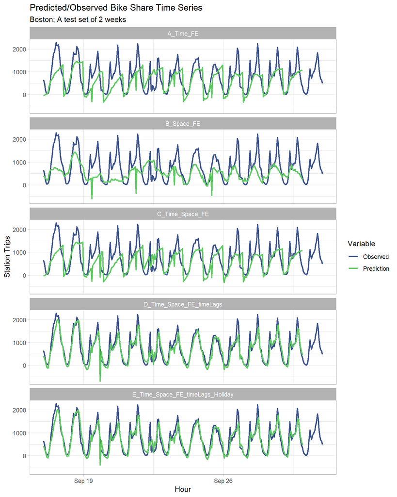

```r
week_predictions %>%
    mutate(interval60 = map(data, pull, interval60),
           start.station.name = map(data, pull, start.station.name)) %>%
    dplyr::select(interval60, start.station.name, Observed, Prediction, Regression) %>%
    unnest() %>%
    gather(Variable, Value, -Regression, -interval60, -start.station.name) %>%
    group_by(Regression, Variable, interval60) %>%
    summarize(Value = sum(Value)) %>%
    ggplot(aes(interval60, Value, color=Variable)) +
      geom_line(size = 1) +
      scale_color_manual(values = c("Observed" = palette2[1], "Prediction" = palette2[2])) +
      facet_wrap(~Regression, ncol=1) +
      labs(title = "Predicted/Observed Bike Share Time Series", subtitle = "Boston; A test set of 2 weeks",  x = "Hour", y= "Station Trips") +
  theme_light()
```

### Cross Validation

Given the marginal difference between Regression D and E, we decide to move forward with Regression E.

The selected model goes through a random k-fold cross-validation, specifically with 10 folds (method = “cv”, number = 10). In this process, the dataset is randomly split into 10 subsets (folds), and the model is trained and evaluated 10 times. Each time, a different fold is used as the test set, while the remaining folds serve as the training set.

The aim of cross-validation is to check how well the model works on different parts of the data. The consistently similar performance metrics (RMSE, Rsquared, and MAE) across the 10 folds suggest that the model generally performs well and is stable across various data subsets.

In Regression E, The RMSE of 2.454967 suggests that, on average, the model’s predictions deviate by approximately 2.46 bike trips from the actual counts. The R² of 0.6578023 indicates that a significant portion (65.8%) of the variability in bike trip counts is captured by the model, suggesting a moderately good fit. The MAE of 1.395702 represents the average absolute difference between predicted and observed bike trip counts.

```r
fitControl <- trainControl(method = "cv", number = 10)
set.seed(123)
# reg.cv4 <-
#   train(Trip_Count ~ ., data = bike.Train %>%
#           dplyr::select(Trip_Count,
#                         start.station.name ,interval60, dotw, Temperature, Precipitation,
#                         lagHour, lag2Hours, lag3Hours, lag12Hours, lag1day),
#         method = "lm", trControl = fitControl, na.action = na.pass)
#
# reg.cv4

reg.cv5 <-
  train(Trip_Count ~ ., data = bike.Train %>%
          dplyr::select(Trip_Count,
                        start.station.name ,interval60, dotw, Temperature, Precipitation,
                        lagHour, lag2Hours, lag3Hours, lag12Hours, lag1day, holiday, holidayLag),
        method = "lm", trControl = fitControl, na.action = na.pass)

reg.cv5

MAE5 <- reg.cv5$resample

write.csv(MAE5, file = "D:\\OneDrive - PennO365\\Semester 3\\PPA\\HW6\\MAE5.csv", row.names = FALSE)
```

[output not shown]

The distribution of Mean Absolute Error (MAE) for this model clusters closely around 1.4, indicating that our model demonstrates good generalizability. In other words, the model performs consistently well on different subsets of the data, and the errors in predictions are relatively stable and close to each other.

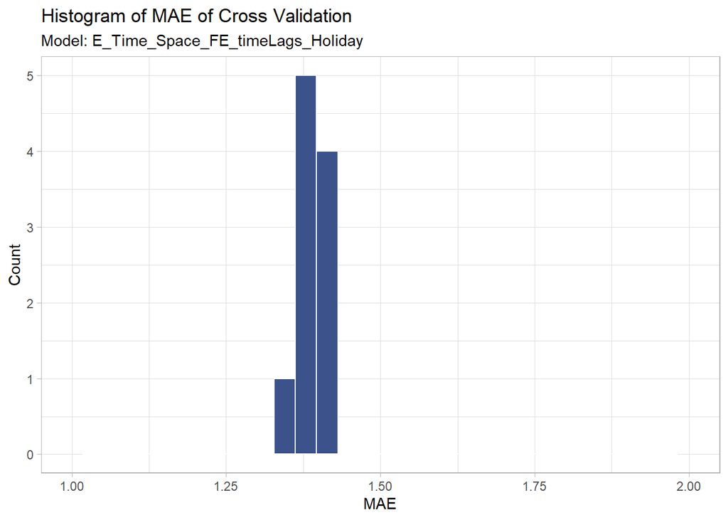

```r
MAE5 <- read.csv("D:\\OneDrive - PennO365\\Semester 3\\PPA\\HW6\\MAE5.csv")

# MAE5 <- reg.cv5$resample

ggplot(MAE5, aes(x=MAE)) +
  geom_histogram(color="white", fill="#3b528b") +
   xlim(1, 2) +
  labs(title = "Histogram of MAE of Cross Validation", subtitle = "Model: E_Time_Space_FE_timeLags_Holiday",  x = "MAE", y= "Count") +
  theme_light()
```

# Conclusion

However, it’s worth noting that the model tends to underpredict during periods of high demand. Further investigation into bike demands during peak hours is necessary to enhance the model and develop more comprehensive re-balancing strategies. The model’s predictive capability could potentially be enhanced by incorporating additional physical features and amenities, such as educational institutes, which likely have an impact on bike demand. Exploring and including such variables in the model could provide a more comprehensive understanding of the factors influencing bike usage patterns. This expanded set of features might lead to a more accurate and nuanced prediction of demand, especially during specific times or in certain areas influenced by the presence of educational institutions.

# References

Boston Transportation Department. (2021, April 15). Bluebikes in 2020. Story Maps. https://storymaps.arcgis.com/stories/0f5fc6ed107d4c0491d24051eed77ff9

Milton, Immanual John. (2023, July 17) Bikeshare Is Still Growing in Popularity After Pandemic Cycling Boom. Bloomberg City Lab. https://www.bloomberg.com/news/articles/2023-07-17/bikeshare-participation-is-growing-fast-in-nyc-boston

Steif, Ken. Public Policy Analytics: Code & Context for Data Science in Government https://urbanspatial.github.io/PublicPolicyAnalytics/index.html